# Purple Air Functions and Validity Tests

# Adam Lang

```r
library(purrr)
library(lubridate)
```

## Purple Air Functions

All of this stuff is still a work in progress and has yet to be cleaned up, but I will run you through the jist of what I have so far. Im looking forward to this long weekend to make more progress and tidy up this code.

This code which I will turn into a function will take the Purple Air Json URL and subset to only the sensors in SLO and just the variables we care about

```r
url <- "https://www.purpleair.org/json"
raw <- RCurl::getURL(url)
d <- jsonlite::fromJSON(raw)
data <- d$results
slo <- data[data$Lon > -120.88 & data$Lon < -120.30
            & data$Lat > 34.97 & data$Lat < 35.79
            & is.na(data$Lat) == FALSE, ]
keepers=c("ID","Label","THINGSPEAK_PRIMARY_ID","THINGSPEAK_PRIMARY_ID_READ_KEY",
          "THINGSPEAK_SECONDARY_ID","THINGSPEAK_SECONDARY_ID_READ_KEY","Lat","Lon","PM2_5Value","LastSeen")
newdata <- slo[keepers]
```

**createurl**  
This function can then take in a Thingspeak ID and Key from the previous dataframe and create a URL that can retreive the JSON data

```r
createurl <- function(id, key){
  url <- paste0("https://api.thingspeak.com/channels/", id,
                "/feeds.json?api_key=", key,
                "&average=60&days=1")
}
```

**mapthrough**  
Using “createurl” I wrote a function called mapthrough which takes all IDs and Keys that we are interested in and creates all URLs we need

```r
mapthrough <- function(df){
  arg1 <-df["THINGSPEAK_PRIMARY_ID"]
  arg2 <-df["THINGSPEAK_PRIMARY_ID_READ_KEY"]
  urlist <-map2_dfr(arg1, arg2, createurl)
  return(urlist)
}
```

Heres what it looks like

```r
mapthrough(newdata)
```

```
## # A tibble: 127 x 1
##    THINGSPEAK_PRIMARY_ID
##    <chr>
##  1 https://api.thingspeak.com/channels/648700/feeds.json?api_key=ML5LCKPZ…
##  2 https://api.thingspeak.com/channels/648702/feeds.json?api_key=I3ESU3V5…
##  3 https://api.thingspeak.com/channels/414921/feeds.json?api_key=QSIPBTTH…
##  4 https://api.thingspeak.com/channels/414923/feeds.json?api_key=7247AJMA…
##  5 https://api.thingspeak.com/channels/300798/feeds.json?api_key=C64IK5IV…
##  6 https://api.thingspeak.com/channels/300800/feeds.json?api_key=E9JXEM7M…
##  7 https://api.thingspeak.com/channels/330428/feeds.json?api_key=WZB5P874…
##  8 https://api.thingspeak.com/channels/330430/feeds.json?api_key=K0ND5PRC…
##  9 https://api.thingspeak.com/channels/314669/feeds.json?api_key=LIMVUYYH…
## 10 https://api.thingspeak.com/channels/314671/feeds.json?api_key=5ETFD0G6…
## # ... with 117 more rows
```

I took one URL just to play around with how I wanted to format the data after retreiving it. Im going to take this idea and write a function that applies it to all URLS. Basically I want to extract the PM2.5 values and format it in a dataframe in a way that my previously defined PM2.5 functions can take it in and assign a NowCast AQI. All this code is doing is making the time variable of a Date/Time class, changing the timezone, and reordering the rows so that the most recent hour is the first row.

```r
url1<-"https://api.thingspeak.com/channels/648700/feeds.json?api_key=ML5LCKPZSF9T4X92&average=60&days=1"
raw1 <- RCurl::getURL(url1)
d1 <- jsonlite::fromJSON(raw1)
d1$feeds$created_at<-as.POSIXct(d1$feeds$created_at, tz = "UTC", "%Y-%m-%dT%H:%M:%SZ")-8*60*60
d1$feeds$created_at<-force_tz(d1$feeds$created_at, tzone = "Etc/GMT+8")
cleandata<-data.frame("Date-Time"=d1$feeds$created_at,"PM2.5"=d1$feeds$field2,
                      "Humidity"=d1$feeds$field7,"Temperature"=d1$feeds$field6)
cleandata<-cleandata[order(nrow(cleandata):1),]

cleandata
```

```
##              Date.Time               PM2.5           Humidity
## 25 2019-01-17 19:00:00  34.915238095238095  68.02380952380952
## 24 2019-01-17 18:00:00  19.967555555555556  68.88888888888889
## 23 2019-01-17 17:00:00  15.226222222222221  69.53333333333333
## 22 2019-01-17 16:00:00  10.993555555555556  70.15555555555555
## 21 2019-01-17 15:00:00  11.389333333333333   65.4888888888889
## 20 2019-01-17 14:00:00   9.568222222222225  61.37777777777778
## 19 2019-01-17 13:00:00   8.234347826086957  63.28260869565217
## 18 2019-01-17 12:00:00   6.462888888888887  63.77777777777778
## 17 2019-01-17 11:00:00   4.057777777777777 63.266666666666666
## 16 2019-01-17 10:00:00  2.9588888888888882   64.5111111111111
## 15 2019-01-17 09:00:00   2.346222222222222  65.22222222222223
## 14 2019-01-17 08:00:00                2.31               65.0
## 13 2019-01-17 07:00:00                <NA>               <NA>
## 12 2019-01-17 06:00:00                <NA>               <NA>
```

[output cut: 37 more lines]

From this it should be pretty quick to write a function that can do this for all pairs of URLs (every device has a URL for each of the two sensors) and then run it through the already defined functions for PM2.5 Nowcast AQI. A little adjustment will be necessary in that it needs to take each pair of sensors and if determined to be valid take the average of both.

## Validity checks for the data

Below is a graph of 50 hours of data from two sensors at a Purple Air device located in Los Osos

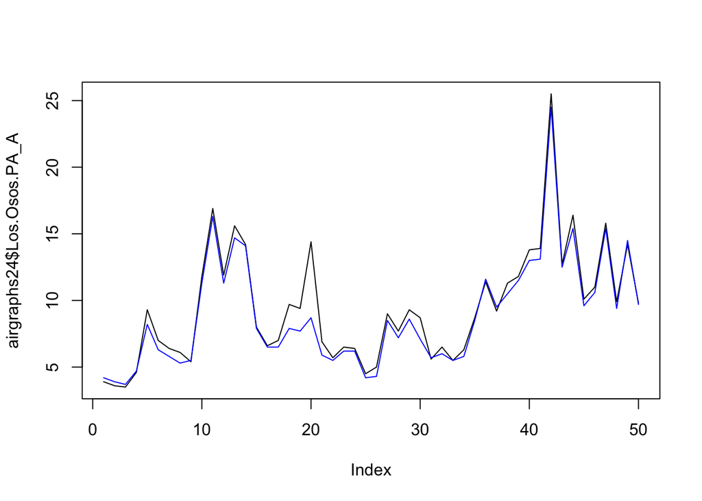

```r
airgraphs<-read.csv(file = "/Users/adamlang/Desktop/PA_AvB.csv")
airgraphs24<-head(airgraphs,50)
plot(airgraphs24$Los.Osos.PA_A,type="l")
lines(airgraphs24$Los.Osos.PA_B, col="blue")
```

I feel that the best approach to determining whether the data is valid is looking at the R Square values between the data of each sensor. I think trying to come up with a model based on percent difference after some threshold and other parameters may introduce a lot of potential error. Since we have a years worth of data, I was thinking we could randomly select around 30% of it, calculate the R Square values between each pair of sensors over a fixed time period, and plot a histogram of the R Square values. Under the assumption that these things are working well most of the time, we should get some sort of Gaussian curve and see what the mean R Square value looks like, and what a poor R Square value looks like. We can them make our decision on what determines valid data from there.

## Next Steps

My progress this week has been slower than I would have liked. It took me a little while just to figure out how these things work, what the end goal is, and what problems need to be solved to get there. I feel now that I have a much better understanding of what needs to be done and can get the ball rolling.

I definitely need to clean a lot of this code up. The readability as of now is pretty poor which im well aware of but I feel like a lot of the greater ideas for what I want to do I have down.